# **CUNEF**

## **Practice III - Retail score analysis**

#### **Machine Learning**</strong>

Pablo Mazariegos Reviriego - pablo.mazariegos@cunef.edu

Mario Sabater Pascual - mario.sabater@cunef.edu

In this Machine Learning practice we will be working with the **Yelp dataset**. The whole practice will be composed by the following notebooks:

1. Data Reading and Problem statement
2. Data selection & variables preparation
3. EDA
4. Model selection
5. **Best Model and Explainability**
6. Variables Relationship (Graphs)

**Creating the prediction Models**

In this notebook we are going to test several models on the selected and transformed data set.

Libraries import and dataset load

Functions

Train, Validation and Test split

Performance Metric Selection

XGBoost

Model explainability

## Libraries import and dataset load

```python
import numpy as np
import pandas as pd
import matplotlib.pyplot as plt
import matplotlib.cm as cm
from matplotlib.patches import Ellipse
import joblib

from sklearn.datasets import make_blobs
from sklearn.datasets import make_moons
from sklearn.metrics import fbeta_score
from sklearn.metrics import silhouette_samples, silhouette_score
from sklearn.model_selection import GridSearchCV
from sklearn.metrics import confusion_matrix, roc_curve, auc

import warnings
warnings.filterwarnings('ignore')
```

**Data Read**

```python
pd.set_option('display.max_columns', 500)
restaurants = pd.read_csv('../data/processed/restaurants_models.csv')
restaurants.tail(3)
```

|  | stars | review_count | is_open | restaurants | food | bars | sandwiches | american (traditional) | pizza | coffee & tea | breakfast & brunch | american (new) | fast food | burgers | mexican | italian | specialty food | seafood | desserts | bakeries | salad | chinese | cafes | chicken wings | ice cream & frozen yogurt | beer | sports bars | cocktail bars | juice bars & smoothies | … |
| --- | --- | --- | --- | --- | --- | --- | --- | --- | --- | --- | --- | --- | --- | --- | --- | --- | --- | --- | --- | --- | --- | --- | --- | --- | --- | --- | --- | --- | --- | --- |
| 50170 | 1.0 | 0.003702 | 1.0 | 1.0 | 1.0 | 0.0 | 0.0 | 0.0 | 0.0 | 1.0 | 0.0 | 0.0 | 0.0 | 0.0 | 0.0 | 0.0 | 0.0 | 0.0 | 0.0 | 0.0 | 0.0 | 0.0 | 1.0 | 0.0 | 0.0 | 0.0 | 0.0 | 0.0 | 1.0 | … |
| 50171 | 1.0 | 0.004760 | 1.0 | 0.0 | 1.0 | 0.0 | 0.0 | 0.0 | 0.0 | 1.0 | 0.0 | 0.0 | 0.0 | 0.0 | 0.0 | 0.0 | 1.0 | 0.0 | 0.0 | 0.0 | 0.0 | 0.0 | 0.0 | 0.0 | 0.0 | 0.0 | 0.0 | 0.0 | 0.0 | … |
| 50172 | 1.0 | 0.003967 | 1.0 | 1.0 | 0.0 | 0.0 | 0.0 | 0.0 | 0.0 | 0.0 | 0.0 | 0.0 | 0.0 | 0.0 | 1.0 | 0.0 | 0.0 | 0.0 | 0.0 | 0.0 | 0.0 | 0.0 | 0.0 | 0.0 | 0.0 | 0.0 | 0.0 | 0.0 | 0.0 | … |

## Functions

```python
def analyze_train_test_performance(clf, X_train, X_test, y_train, y_test):

    '''Analyze Train and Test Performance'''

    # get predictions
    y_pred_train = clf.predict(X_train)
    y_pred_test  = clf.predict(X_test)

    # get confusion matrices
    confmat_train = confusion_matrix(y_train, y_pred_train)
    confmat_test  = confusion_matrix(y_test, y_pred_test)

    # Plot confusion matrices and provide metrics
    print_performance_metrics(confmat_train, confmat_test)
    plot_confusion_matrix(confmat_train, confmat_test)

    # Plot ROC curve
    y_prob = clf.predict_proba(X_test)[:,1]
    plot_roc_curve(y_test,y_prob)
```

```python
# Para f0.5 score:

from sklearn.metrics import fbeta_score

def hyper_parameters_search(clf, X, y, param_grid, scorer = fbeta_score, beta=0.5, cv=5):

    grid = GridSearchCV(clf, param_grid = param_grid, scoring = scorer, cv = cv)
    grid.fit(X, y)

    print("best mean cross-validation score: {:.3f}".format(grid.best_score_))
    print("best parameters: {}".format(grid.best_params_))

    return grid
```

```python
def print_performance_metrics(confmat_train, *confmat_test):
    '''Print performance metrics'''

    if not confmat_test:
        acc, sen, esp, ppv, fsc = get_metrics(confmat_train)
        print('ACC: %2.2f' %(100*acc))
        print('SEN: %2.2f' %(100*sen))
        print('ESP: %2.2f' %(100*esp))
        print('PPV: %2.2f' %(100*ppv))
        print('F0.5: %2.2f' %(100*fsc))
    else:
        acc_train, sen_train, esp_train, ppv_train, fsc_train = get_metrics(confmat_train)
        acc_test, sen_test, esp_test, ppv_test, fsc_test = get_metrics(confmat_test[0])

        print('PERFORMANCE METRICS')
        print('\tTRAIN\tTEST')
        print('ACC:\t%2.2f\t%2.2f' %(100*acc_train, 100*acc_test))
        print('SEN:\t%2.2f\t%2.2f' %(100*sen_train, 100*sen_test))
        print('ESP:\t%2.2f\t%2.2f' %(100*esp_train, 100*esp_test))
        print('PPV:\t%2.2f\t%2.2f' %(100*ppv_train, 100*ppv_test))
        print('F0.5:\t%2.2f\t%2.2f'  %(100*fsc_train, 100*fsc_test))
```

```python
def get_metrics(confmat):
    '''Unravel confusion matrix and calculate performance metrics'''
    tn, fp, fn, tp = confmat.ravel()

    acc = (tp+tn)/(tn + fp + fn + tp)
    sen = tp/(tp+fn)
    esp = tn/(tn+fp)
    ppv = tp/(tp+fp)
    fsc = 2*(sen*ppv)/(sen+ppv)

    return acc, sen, esp, ppv, fsc
```

```python
def plot_confusion_matrix(confmat_train, *confmat_test):
    ''' Plot confusion matrix
        - A single confusion matrix
        - Comparing two confusion matrices, if provided
    '''

    if not confmat_test:
        fig, ax = plt.subplots(figsize=(3, 3))
        ax.matshow(confmat_train, cmap=plt.cm.Blues, alpha=0.5)
        for i in range(confmat_train.shape[0]):
            for j in range(confmat_train.shape[1]):
                ax.text(x=j, y=i, s=confmat_train[i, j], va='center', ha='center')

        plt.xlabel('predicted label')
        plt.ylabel('true label')

        plt.tight_layout()
        plt.show()

    else:
        fig, ax = plt.subplots(1,2,figsize=(6, 6))
        ax[0].matshow(confmat_train, cmap=plt.cm.Blues, alpha=0.5)
        for i in range(confmat_train.shape[0]):
            for j in range(confmat_train.shape[1]):
                ax[0].text(x=j, y=i, s=confmat_train[i, j], va='center', ha='center')

        ax[1].matshow(confmat_test[0], cmap=plt.cm.Blues, alpha=0.5)
        for i in range(confmat_test[0].shape[0]):
            for j in range(confmat_test[0].shape[1]):
                ax[1].text(x=j, y=i, s=confmat_test[0][i, j], va='center', ha='center')

        ax[0].set_xlabel('predicted label')
        ax[0].set_ylabel('true label')
        ax[0].set_title('TRAIN')

        ax[1].set_xlabel('predicted label')
        ax[1].set_ylabel('true label')
        ax[1].set_title('TEST')

        plt.tight_layout()
        plt.show()
```

```python
def plot_roc_curve(y,y_prob):

    '''Plot ROC-AUC Curve and target probability'''

    ejex, ejey, _ = roc_curve(y, y_prob)
    roc_auc = auc(ejex, ejey)

    plt.figure(figsize = (12,4))

    # ROC-AUC CURVE
    plt.subplot(1,2,1)
    plt.plot(ejex, ejey, color='darkorange',lw=2, label='AUC = %0.2f' % roc_auc)
    plt.plot([0, 1], [0, 1], color=(0.6, 0.6, 0.6), linestyle='--')
    plt.plot([0, 0, 1],[0, 1, 1],lw=2, linestyle=':',color='black',label='Perfect classifier')
    plt.xlim([-0.05, 1.05])
    plt.ylim([-0.05, 1.05])
    plt.xlabel('FPR (1-ESP)')
    plt.ylabel('SEN')
    plt.legend(loc="lower right")

    # PROB DENSITY
    idx_0 = (y==0)
    idx_1 = (y==1)

    plt.subplot(1,2,2)
    plt.hist(y_prob[idx_0],density=1,bins = 20, label='y=0',alpha=0.5)
    plt.hist(y_prob[idx_1],density=1,bins = 20, facecolor='red',label='y=1',alpha=0.5)
    plt.legend()
    plt.xlabel('target probability')

    plt.show()
```

```python
def plot_threshold(model, x_train_scaled, x_test_scaled, y_train, y_test):
        # predicción de TRAIN
    pd_train_predicted = pd.DataFrame(model.predict_proba(x_train_scaled),
                                    index=x_train_scaled.index, columns = ['y_predicted_0', 'y_predicted']).drop(['y_predicted_0'],axis=1)
    pd_train_predicted_final = pd.concat([x_train_scaled, pd_train_predicted, y_train],axis=1)

    prob_predictions = pd_train_predicted_final.y_predicted.values
    recall_precision = []

    for threshold in np.arange(0.01, 0.99, 0.01):

        given_threshold = [1 if value>threshold else 0 for value in prob_predictions]
        recall_precision.append([threshold, recall_score(pd_train_predicted_final.stars, given_threshold),
                                precision_score(pd_train_predicted_final.stars, given_threshold)])

    matplotlib.rcParams.update(matplotlib.rcParamsDefault)
    plot_recall_precission(recall_precision)
```

```python
def plot_recall_precission(recall_precision):

    plt.figure(figsize=(15, 5))
    ax = sns.pointplot(x = [element[0] for element in recall_precision], y=[element[1] for element in recall_precision],
                     color="r", label='recall', scale=1)
    ax = sns.pointplot(x = [element[0] for element in recall_precision], y=[element[2] for element in recall_precision],
                     color="b", label='precission')
    ax.set_title('recall-precision versus threshold')
    ax.set_xlabel('threshold')
    ax.set_ylabel('probability')
    ax.legend()

    labels = ax.get_xticklabels()
    for i,l in enumerate(labels):
        if(i%5 == 0) or (i%5 ==1) or (i%5 == 2) or (i%5 == 3):
            labels[i] = '' # skip even labels
            ax.set_xticklabels(labels, rotation=45, fontdict={'size': 10})
    plt.show()
```

## Train, Validation and Test split

```python
seed = 12345
```

Before splitting into train and test, we will separate the between the target variable and all the rest of the variables, becoming X and Y respectively.

```python
y = restaurants['stars'] #stars would be our y variable, the one we want to predict
X = restaurants.drop('stars', axis = 1) #X would be the whole dataset without the stars variable.
```

Now we separate both into train + validation (x and y) and test (x_test, y_test)

```python
from sklearn.model_selection import train_test_split

X_train, X_test, y_train, y_test = train_test_split(X, y, stratify=y, test_size=0.30, random_state=seed)
```

```python
y.sum()/len(y)
```

```
0.4766707193111833
```

```python
y_test.sum()/len(y_test)
```

```
0.47668083975551423
```

We observe that both train and test have the same proportion of "stars1, hence we continue with the spit

## Performance Metric Selection

**Accuracy:** It’s the ratio of the correctly labeled subjects to the whole pool of subjects in this case Accuracy answers the following question: How many restaurants did we correctly label out of all the restaurants?

**Sensitivity:** Recall or sensitivity is the ratio of the correctly labeled stars( if its more than 4 would be a successful restaurant) by our program to all who are stars in reality. Recall answers the following question: Of all the succesful restaurantes that got more than 4 stars, how many of those we correctly predict?

**Specificity** is the correctly labeled as no stars( if its more than 4 would be a successful restaurant) by the program to all who are no stars restaurants in reality. Specifity answers the following question: of all the succesful restaurants that we declared unsuccesful, how many of those did we correctly predict?

**F0.5-score** is the weighted harmonic mean of the precision and recall (given a threshold value). Unlike the F1 score, which gives equal weight to precision and recall, the F0. 5 score gives more weight to precision than to recall.

**Precision** or Positive Predictive Value is the ratio of the correctly labeled as stars( if its more than 4 would be a successful restaurant) by our program to all stars labeled. Precision answers the following: How many of those restaurants label success are actually a success?

*stars( if its more than 4 would be a successful restaurant)

[figure not shown]

Putting ourselves in the selling point of view of the model for predicting what kind of restaurant would be successful. We consider that it is a 'class labels' problem, and within the two possibilities, being a successful restaurant is more important than not being a successful restaurant. Failure would be in the case that an investor makes the investment and does not obtain the predicted results. In conclusion, the necessary metric for this problem is 'f0.5'.

## **XGBOOST Model**

XGBoost is the abbreviation for the English words "extreme gradient boosting." This method is based on decision trees and is an improvement over other methods. It works well with large and complex datasets by using multiple optimization methods.

## **XGBOOST Hyperparameters**

Hyperparameters are values that are used to control the operation of a machine learning algorithm. In this case, hyperparameters are being specified for a gradient boosting model called XGBoost.

The specified hyperparameters include:

**subsample:** This hyperparameter controls the amount of training samples used for each tree in the model. A higher value means more samples will be used, which can improve model accuracy but may also increase training time.

**max_depth:** This hyperparameter controls the maximum depth of each tree in the model. A greater depth can allow the model to capture more complex patterns, but may also increase the risk of overfitting.

**gamma:** This hyperparameter controls the minimum loss required to make an additional split at a tree node. A higher value means a greater loss is required to make a split, which can reduce overfitting.

**reg_alpha:** This hyperparameter controls the L1 regularization term in the model loss. A higher value means more penalty will be added for large weight coefficients in the model, which can help reduce overfitting.

**reg_lambda:** This hyperparameter controls the L2 regularization term in the model loss. A higher value means more penalty will be added for large weight coefficients in the model, which can help reduce overfitting.

**colsample_bytree:** This hyperparameter controls the amount of features used for each tree in the model. A higher value means more features will be used, which can improve model accuracy but may also increase training time.

**min_child_weight:** This hyperparameter controls the minimum loss required to make an additional split at a tree node with a minimum number of samples. A higher value means a greater loss is required to make a split, which can reduce overfitting.

**n_estimators:** This hyperparameter controls the number of trees in the model. A higher value may improve model accuracy but may also increase training time and model size.

**learning_rate:** This hyperparameter controls the learning rate of the model. A lower value means the model will have greater accuracy but may also require more trees and training time to converge.

## XGBoost

**Hyperparameters**

```python
# XGBOOST Hyperparameters
params = {"subsample":[0.25,0.5, 0.75, 1],
          "colsample_bytree":[0.25,0.5, 0.75, 1],
          "max_depth":[2, 4, 6, 8, 10, 15, 20],
          "min_child_weight":[1, 2, 3, 4, 5, 10, 15, 20],
          "learning_rate":[0.9,0.6,0.3, 0.1, 0.03, 0.01],
          "n_estimators":[100],
          "gamma": [0.05, 0.1, 0.15, 2],
          "reg_alpha": [0.05, 0.1, 0.15, 2],
          "reg_lambda": [0.05, 0.1, 0.15, 2],
         }
```

**RandomizedSearchCV :** performs a randomized search for hyperparameter optimization. It takes an estimator (such as a classifier), a parameter distribution, and a number of other optional parameters as input, and it returns an optimized estimator that has been fit to the data.

```python
from sklearn.metrics import fbeta_score
import xgboost
from sklearn.model_selection import  RandomizedSearchCV
from sklearn.metrics import make_scorer
from xgboost import XGBClassifier

# We use the prevous test model again:
xgb = XGBClassifier(random_state = seed, n_jobs=-1).fit(X_train ,y_train)

# RandomizedSearchCV over the test model qith the params and the f0.5 score:
best_xgb = RandomizedSearchCV(xgb,params,cv=3,scoring=make_scorer(fbeta_score, beta=0.5), random_state = seed)

# We obtain the best parameters and we do the fit wit the X_train and y_train:
best_xgb = best_xgb.fit(X_train, y_train)

# Print of the best parameters that the best_xgb model is using
print(best_xgb.best_params_)

# we save the model for future use
joblib.dump(best_xgb, "../models/best_xgb.joblib")
```

```
{'subsample': 0.75, 'reg_lambda': 0.1, 'reg_alpha': 2, 'n_estimators': 100, 'min_child_weight': 2, 'max_depth': 6, 'learning_rate': 0.3, 'gamma': 2, 'colsample_bytree': 0.5}
```

```
['../models/best_xgb.joblib']
```

**being the best hyperparameters for our model:**

```
-'subsample': 0.75
-reg_lambda': 0.1
-'reg_alpha': 2
-'n_estimators': 100
-'min_child_weight': 2
-'max_depth': 6
-'learning_rate': 0.3
-'gamma': 2
-'colsample_bytree': 0.5
```

**Best estimator**

best_xgb.best*estimator* is an attribute of the RandomizedSearchCV object that returns the best estimator found by the search.

```python
best_xgb.best_estimator_
```

```
XGBClassifier(base_score=None, booster=None, callbacks=None,
              colsample_bylevel=None, colsample_bynode=None,
              colsample_bytree=0.5, early_stopping_rounds=None,
              enable_categorical=False, eval_metric=None, feature_types=None,
              gamma=2, gpu_id=None, grow_policy=None, importance_type=None,
              interaction_constraints=None, learning_rate=0.3, max_bin=None,
              max_cat_threshold=None, max_cat_to_onehot=None,
              max_delta_step=None, max_depth=6, max_leaves=None,
              min_child_weight=2, missing=nan, monotone_constraints=None,
              n_estimators=100, n_jobs=-1, num_parallel_tree=None,
              predictor=None, random_state=12345, ...)
```

## Evaluation of model metrics

```
 -Metrics: Accuracy, Sensitivity, Specificity, F0.5-score and F1 Precision
 -Confusion matrix
 -ROC curve
```

[output not shown]

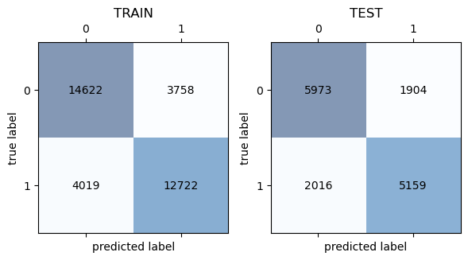

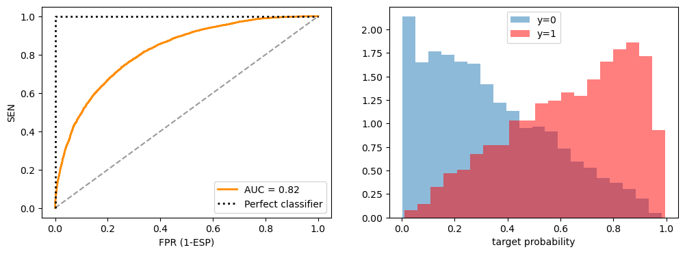

```python
# Load of the best model
loaded_xgb = joblib.load("../models/best_xgb.joblib")

# analyze, plot and score of the data set with the best model
analyze_train_test_performance(best_xgb ,X_train,X_test,y_train,y_test)
```

**Accuracy:** In this case $77.86\%$ in the training set and in the test set $73.96\%$.

**Sensitivity:** In this case $75.99$ in the training set and $71.90$ in the test set.

**Specificity** In this case for the training set $79.55\%$ and for the test set $75.83\%$.

**Precision** In this case we have for the train set $77.20\%$ and for the test set $73.04\%$.

Observing the ROC curve, we observe that the area under the curve is 0.82 a relatively high value taking into account that a perfect model will yield an area of 1.

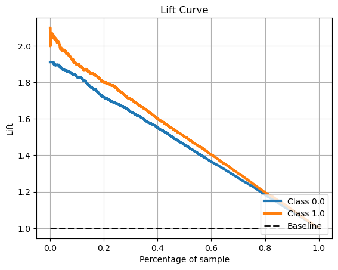

```python
import scikitplot as skplt

# Plot the lift curve.

skplt.metrics.plot_lift_curve(y_test, predict_probabilities)
plt.show()
```

When the class is 0, the model has an initial Lift performance of 1.9, which means that the model is 1.9 times more effective than the random prediction. As the sample percentage increases, the Lift value decreases until it reaches 1, which means that the model has the same performance as the random prediction.

For class 1, the model has an initial Lift performance of 2.0, which means that the model is 2 times more effective than the random prediction. Then, the Lift value takes a time jump to 2.1 before steadily decreasing until it reaches 1. This indicates that the model performs better than the random prediction at first, but its performance decreases as the sample percentage increases.

In general, a model with a Lift performance consistently above 1 is considered a good model, while a model with a Lift performance consistently below 1 is considered a poor model.

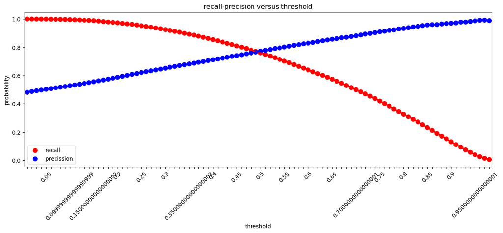

```python
from sklearn.metrics import r2_score, precision_recall_curve, recall_score, precision_score, auc
from sklearn.metrics import classification_report, fbeta_score, ConfusionMatrixDisplay, confusion_matrix
from sklearn.metrics import accuracy_score, roc_auc_score, roc_curve, precision_recall_curve, average_precision_score
import matplotlib
import seaborn as sns

plot_threshold(best_xgb, X_train, X_test, y_train, y_test)
```

## **Model prediction**

Once the XGB model has been optimized, we will proceed to predict the validation set, its values and probabilities. Then we will obtain the metrics and observe how the model and its score behave.

```python
# Predict the target value of the validation set.

predictions = best_xgb.predict(X_test)

# Predict the probabilities of the target value for the validation set.

predict_probabilities = best_xgb.predict_proba(X_test)
```

Once the probabilities are obtained, we plot the prediction density histogram:

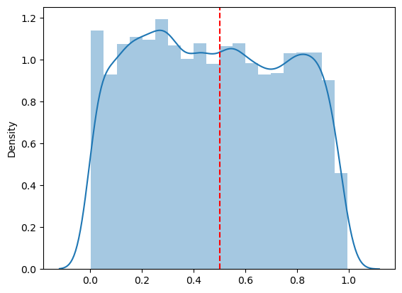

```python
# Parametric density histogram of the predicted probabilities, shwoing the treshold of 0.5.

sns.distplot(predict_probabilities[:,1], kde=True, rug=False, bins=20)
plt.axvline(x=0.5, color='r', linestyle='--')
plt.show()
```

## Model explainability

```python
from xgboost import XGBClassifier
import eli5
from eli5.sklearn import PermutationImportance

# Decision trees
xgb = XGBClassifier(random_state = 0, n_jobs=-1).fit(X_train ,y_train)


perm = PermutationImportance(xgb, random_state=1).fit(X_test, y_test)
eli5.show_weights(perm, feature_names = X.columns.tolist())
```

| Weight | Feature |
| --- | --- |
| 0.0335 ± 0.0020 | num_hours_open |
| 0.0291 ± 0.0076 | review_count |
| 0.0193 ± 0.0017 | num_days_open |
| 0.0134 ± 0.0010 | Alcohol |
| 0.0098 ± 0.0027 | BusinessAcceptsCreditCards |
| 0.0093 ± 0.0018 | fast food |
| 0.0073 ± 0.0022 | RestaurantsDelivery |
| 0.0066 ± 0.0019 | WheelchairAccessible |
| 0.0053 ± 0.0024 | average_income |
| 0.0050 ± 0.0020 | RestaurantsPriceRange2 |
| 0.0045 ± 0.0018 | DriveThru |
| 0.0044 ± 0.0032 | RestaurantsTableService |
| 0.0040 ± 0.0029 | food |
| 0.0036 ± 0.0014 | DogsAllowed |
| 0.0027 ± 0.0010 | specialty food |
| 0.0027 ± 0.0019 | chinese |
| 0.0026 ± 0.0014 | local flavor |
| 0.0026 ± 0.0008 | is_open |
| 0.0025 ± 0.0006 | pizza |
| 0.0024 ± 0.0027 | HasTV |
| *… 97 more …* |  |

### SHAP Values

Each feature value is a force that either increases or decreases the prediction. The prediction starts from the baseline. The baseline for Shapley values is the average of all predictions. In the plot, each Shapley value is an arrow that pushes to increase (positive value) or decrease (negative value) the prediction. These forces balance each other out at the actual prediction of the data instance.

```python
import shap
```

**Global explainability**

The global explainability will allow us to understand how the different values of the variables affect to the model in general, making the prediction being higher or lower. In order to do this we use the TreeExplainer from the shap library.

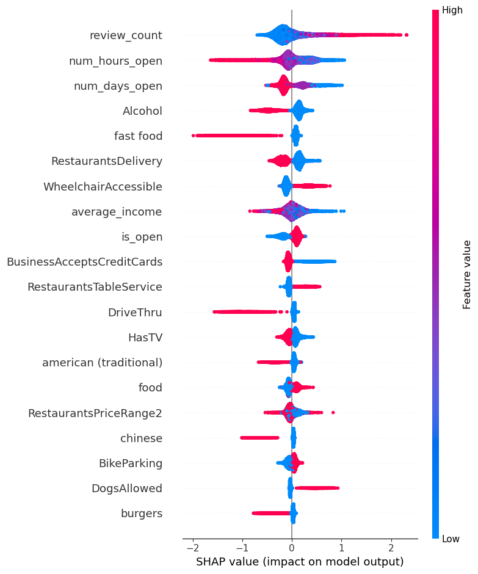

```python
explainer = shap.TreeExplainer(best_xgb.best_estimator_)
shap_values = explainer.shap_values(X_test)
shap.summary_plot(shap_values, X_test)
```

As we can see above, the higher the value of review_count, WheelchairAccessible, RestaurantsTableService and DogsAllowed will lead to a higher probabiliy of it being successfull (a 1 in stars value, which transalates to having 4 stars or more).

On the other side high values of number of hours and days opened, the restaurant having delivery or drive thru as well as be classified under the categories of alcohol, fast food, american, chinese or burguers, will lead to more chances of not being sucessfull.

Other variables such as average income, or price range are more ambiguous.

**Local explainability**

Contrary to the global explainability, the local allow us to understand the decission make by the model for a single business. In some industries the regulatory body can request an explanation on why a decission has been made. If such decission is made through a machine learning model, the local explainability allows to show which variables and the weight of them have made the model to take such decission.

```python
shap.initjs()
```

```python
# Using a random sample of the dataframe for better time computation
X_sampled = X_train.sample(100, random_state=seed)
```

```python
# explain the model's predictions using SHAP values
# (same syntax works for LightGBM, CatBoost, and scikit-learn models)
explainer = shap.TreeExplainer(best_xgb.best_estimator_)
shap_values = explainer.shap_values(X_sampled)
```

```python
# visualize the first prediction's explanation
shap.force_plot(explainer.expected_value, shap_values[1,:], X_sampled.iloc[1,:])
```

[output not shown]

```python
shap.force_plot(explainer.expected_value, shap_values, X_train)
```

[output not shown]